# Risk Factor Analysis

## Outcome Variable

**Outcome Variable:** ever_swasted

## Predictor Variables

**Intervention Variable:** mhtcm

**Adjustment Set:**

- arm
- W_mage
- meducyrs
- feducyrs
- delta_W_mage
- delta_meducyrs
- delta_feducyrs

## Stratifying Variables

The analysis was stratified on these variable(s):

- agecat
- studyid
- country

## Data Summary

| agecat | studyid | country | mhtcm | ever_swasted | n_cell | n |
| --- | --- | --- | --- | --- | --- | --- |
| 0-24 months | COHORTS | GUATEMALA | >=155 cm | 0 | 149 | 1275 |
| 0-24 months | COHORTS | GUATEMALA | >=155 cm | 1 | 16 | 1275 |
| 0-24 months | COHORTS | GUATEMALA | <151 cm | 0 | 772 | 1275 |
| 0-24 months | COHORTS | GUATEMALA | <151 cm | 1 | 63 | 1275 |
| 0-24 months | COHORTS | GUATEMALA | [151-155) cm | 0 | 257 | 1275 |
| 0-24 months | COHORTS | GUATEMALA | [151-155) cm | 1 | 18 | 1275 |
| 0-24 months | COHORTS | INDIA | >=155 cm | 0 | 514 | 1905 |
| 0-24 months | COHORTS | INDIA | >=155 cm | 1 | 57 | 1905 |
| 0-24 months | COHORTS | INDIA | <151 cm | 0 | 736 | 1905 |
| 0-24 months | COHORTS | INDIA | <151 cm | 1 | 87 | 1905 |
| 0-24 months | COHORTS | INDIA | [151-155) cm | 0 | 458 | 1905 |
| 0-24 months | COHORTS | INDIA | [151-155) cm | 1 | 53 | 1905 |
| 0-24 months | COHORTS | PHILIPPINES | >=155 cm | 0 | 549 | 3045 |
| 0-24 months | COHORTS | PHILIPPINES | >=155 cm | 1 | 80 | 3045 |
| 0-24 months | COHORTS | PHILIPPINES | <151 cm | 0 | 1346 | 3045 |
| 0-24 months | COHORTS | PHILIPPINES | <151 cm | 1 | 194 | 3045 |
| 0-24 months | COHORTS | PHILIPPINES | [151-155) cm | 0 | 768 | 3045 |
| 0-24 months | COHORTS | PHILIPPINES | [151-155) cm | 1 | 108 | 3045 |
| 0-24 months | Guatemala BSC | GUATEMALA | >=155 cm | 0 | 36 | 235 |
| 0-24 months | Guatemala BSC | GUATEMALA | >=155 cm | 1 | 0 | 235 |
| 0-24 months | Guatemala BSC | GUATEMALA | <151 cm | 0 | 141 | 235 |
| 0-24 months | Guatemala BSC | GUATEMALA | <151 cm | 1 | 2 | 235 |
| 0-24 months | Guatemala BSC | GUATEMALA | [151-155) cm | 0 | 56 | 235 |
| 0-24 months | Guatemala BSC | GUATEMALA | [151-155) cm | 1 | 0 | 235 |
| 0-24 months | iLiNS-Zinc | BURKINA FASO | >=155 cm | 0 | 2770 | 3217 |
| 0-24 months | iLiNS-Zinc | BURKINA FASO | >=155 cm | 1 | 130 | 3217 |
| 0-24 months | iLiNS-Zinc | BURKINA FASO | <151 cm | 0 | 82 | 3217 |
| 0-24 months | iLiNS-Zinc | BURKINA FASO | <151 cm | 1 | 9 | 3217 |
| 0-24 months | iLiNS-Zinc | BURKINA FASO | [151-155) cm | 0 | 211 | 3217 |
| 0-24 months | iLiNS-Zinc | BURKINA FASO | [151-155) cm | 1 | 15 | 3217 |

[output cut: 378 more lines]

The following strata were considered:

- agecat: 0-24 months, studyid: COHORTS, country: GUATEMALA
- agecat: 0-24 months, studyid: COHORTS, country: INDIA
- agecat: 0-24 months, studyid: COHORTS, country: PHILIPPINES
- agecat: 0-24 months, studyid: Guatemala BSC, country: GUATEMALA
- agecat: 0-24 months, studyid: iLiNS-Zinc, country: BURKINA FASO
- agecat: 0-24 months, studyid: JiVitA-3, country: BANGLADESH
- agecat: 0-24 months, studyid: Keneba, country: GAMBIA
- agecat: 0-24 months, studyid: LCNI-5, country: MALAWI
- agecat: 0-24 months, studyid: MAL-ED, country: BANGLADESH
- agecat: 0-24 months, studyid: MAL-ED, country: BRAZIL
- agecat: 0-24 months, studyid: MAL-ED, country: INDIA
- agecat: 0-24 months, studyid: MAL-ED, country: NEPAL
- agecat: 0-24 months, studyid: MAL-ED, country: PERU
- agecat: 0-24 months, studyid: MAL-ED, country: SOUTH AFRICA
- agecat: 0-24 months, studyid: MAL-ED, country: TANZANIA, UNITED REPUBLIC OF
- agecat: 0-24 months, studyid: NIH-Birth, country: BANGLADESH
- agecat: 0-24 months, studyid: NIH-Crypto, country: BANGLADESH
- agecat: 0-24 months, studyid: PROBIT, country: BELARUS
- agecat: 0-24 months, studyid: PROVIDE, country: BANGLADESH
- agecat: 0-24 months, studyid: SAS-CompFeed, country: INDIA
- agecat: 0-24 months, studyid: SAS-FoodSuppl, country: INDIA
- agecat: 0-24 months, studyid: TanzaniaChild2, country: TANZANIA, UNITED REPUBLIC OF
- agecat: 0-24 months, studyid: ZVITAMBO, country: ZIMBABWE
- agecat: 0-6 months, studyid: COHORTS, country: GUATEMALA
- agecat: 0-6 months, studyid: COHORTS, country: INDIA
- agecat: 0-6 months, studyid: COHORTS, country: PHILIPPINES
- agecat: 0-6 months, studyid: Guatemala BSC, country: GUATEMALA
- agecat: 0-6 months, studyid: JiVitA-3, country: BANGLADESH
- agecat: 0-6 months, studyid: Keneba, country: GAMBIA
- agecat: 0-6 months, studyid: LCNI-5, country: MALAWI
- agecat: 0-6 months, studyid: MAL-ED, country: BANGLADESH
- agecat: 0-6 months, studyid: MAL-ED, country: BRAZIL
- agecat: 0-6 months, studyid: MAL-ED, country: INDIA
- agecat: 0-6 months, studyid: MAL-ED, country: NEPAL
- agecat: 0-6 months, studyid: MAL-ED, country: PERU
- agecat: 0-6 months, studyid: MAL-ED, country: SOUTH AFRICA
- agecat: 0-6 months, studyid: MAL-ED, country: TANZANIA, UNITED REPUBLIC OF
- agecat: 0-6 months, studyid: NIH-Birth, country: BANGLADESH
- agecat: 0-6 months, studyid: NIH-Crypto, country: BANGLADESH
- agecat: 0-6 months, studyid: PROBIT, country: BELARUS
- agecat: 0-6 months, studyid: PROVIDE, country: BANGLADESH
- agecat: 0-6 months, studyid: SAS-CompFeed, country: INDIA
- agecat: 0-6 months, studyid: SAS-FoodSuppl, country: INDIA
- agecat: 0-6 months, studyid: TanzaniaChild2, country: TANZANIA, UNITED REPUBLIC OF
- agecat: 0-6 months, studyid: ZVITAMBO, country: ZIMBABWE
- agecat: 6-24 months, studyid: COHORTS, country: GUATEMALA
- agecat: 6-24 months, studyid: COHORTS, country: INDIA
- agecat: 6-24 months, studyid: COHORTS, country: PHILIPPINES
- agecat: 6-24 months, studyid: Guatemala BSC, country: GUATEMALA
- agecat: 6-24 months, studyid: iLiNS-Zinc, country: BURKINA FASO
- agecat: 6-24 months, studyid: JiVitA-3, country: BANGLADESH
- agecat: 6-24 months, studyid: Keneba, country: GAMBIA
- agecat: 6-24 months, studyid: LCNI-5, country: MALAWI
- agecat: 6-24 months, studyid: MAL-ED, country: BANGLADESH
- agecat: 6-24 months, studyid: MAL-ED, country: BRAZIL
- agecat: 6-24 months, studyid: MAL-ED, country: INDIA
- agecat: 6-24 months, studyid: MAL-ED, country: NEPAL
- agecat: 6-24 months, studyid: MAL-ED, country: PERU
- agecat: 6-24 months, studyid: MAL-ED, country: SOUTH AFRICA
- agecat: 6-24 months, studyid: MAL-ED, country: TANZANIA, UNITED REPUBLIC OF
- agecat: 6-24 months, studyid: NIH-Birth, country: BANGLADESH
- agecat: 6-24 months, studyid: NIH-Crypto, country: BANGLADESH
- agecat: 6-24 months, studyid: PROBIT, country: BELARUS
- agecat: 6-24 months, studyid: PROVIDE, country: BANGLADESH
- agecat: 6-24 months, studyid: SAS-CompFeed, country: INDIA
- agecat: 6-24 months, studyid: SAS-FoodSuppl, country: INDIA
- agecat: 6-24 months, studyid: TanzaniaChild2, country: TANZANIA, UNITED REPUBLIC OF
- agecat: 6-24 months, studyid: ZVITAMBO, country: ZIMBABWE

### Dropped Strata

Some strata were dropped due to rare outcomes:

- agecat: 0-24 months, studyid: Guatemala BSC, country: GUATEMALA
- agecat: 0-24 months, studyid: LCNI-5, country: MALAWI
- agecat: 0-24 months, studyid: MAL-ED, country: BANGLADESH
- agecat: 0-24 months, studyid: MAL-ED, country: BRAZIL
- agecat: 0-24 months, studyid: MAL-ED, country: INDIA
- agecat: 0-24 months, studyid: MAL-ED, country: NEPAL
- agecat: 0-24 months, studyid: MAL-ED, country: PERU
- agecat: 0-24 months, studyid: MAL-ED, country: SOUTH AFRICA
- agecat: 0-24 months, studyid: MAL-ED, country: TANZANIA, UNITED REPUBLIC OF
- agecat: 0-6 months, studyid: Guatemala BSC, country: GUATEMALA
- agecat: 0-6 months, studyid: LCNI-5, country: MALAWI
- agecat: 0-6 months, studyid: MAL-ED, country: BANGLADESH
- agecat: 0-6 months, studyid: MAL-ED, country: BRAZIL
- agecat: 0-6 months, studyid: MAL-ED, country: INDIA
- agecat: 0-6 months, studyid: MAL-ED, country: NEPAL
- agecat: 0-6 months, studyid: MAL-ED, country: PERU
- agecat: 0-6 months, studyid: MAL-ED, country: SOUTH AFRICA
- agecat: 0-6 months, studyid: MAL-ED, country: TANZANIA, UNITED REPUBLIC OF
- agecat: 0-6 months, studyid: SAS-FoodSuppl, country: INDIA
- agecat: 6-24 months, studyid: COHORTS, country: GUATEMALA
- agecat: 6-24 months, studyid: Guatemala BSC, country: GUATEMALA
- agecat: 6-24 months, studyid: LCNI-5, country: MALAWI
- agecat: 6-24 months, studyid: MAL-ED, country: BANGLADESH
- agecat: 6-24 months, studyid: MAL-ED, country: BRAZIL
- agecat: 6-24 months, studyid: MAL-ED, country: INDIA
- agecat: 6-24 months, studyid: MAL-ED, country: NEPAL
- agecat: 6-24 months, studyid: MAL-ED, country: PERU
- agecat: 6-24 months, studyid: MAL-ED, country: SOUTH AFRICA
- agecat: 6-24 months, studyid: MAL-ED, country: TANZANIA, UNITED REPUBLIC OF
- agecat: 6-24 months, studyid: NIH-Crypto, country: BANGLADESH
- agecat: 6-24 months, studyid: PROBIT, country: BELARUS
- agecat: 6-24 months, studyid: PROVIDE, country: BANGLADESH

## Methods Detail

We’re interested in the causal parameters $E[Y_a]$ for all values of $a \in \mathcal{A}$. These parameters represent the mean outcome if, possibly contrary to fact, we intervened to set all units to have $A=a$. Under the randomization and positivity assumptions, these are identified by the statistical parameters $\psi_a=E_W[E_{Y|A,W}(Y|A=a,W)]$. In addition, we’re interested in the mean of $Y$, $E[Y]$ under no intervention (the observed mean). We will estimate these parameters by using SuperLearner to fit the relevant likelihood factors – $E_{Y|A,W}(Y|A=a,W)$ and $p(A=a|W)$, and then updating our likelihood fit using a joint TMLE.

For unadjusted analyses ($W=\{\}$), initial likelihoods were estimated using Lrnr_glm to estimate the simple $E(Y|A)$ and Lrnr_mean to estimate $p(A)$. For adjusted analyses, a small library containing Lrnr_glmnet, Lrnr_xgboost, and Lrnr_mean was used.

Having estimated these parameters, we will then use the delta method to estimate relative risks and attributable risks relative to a prespecified baseline level of $A$.

# Results Detail

## Results Plots

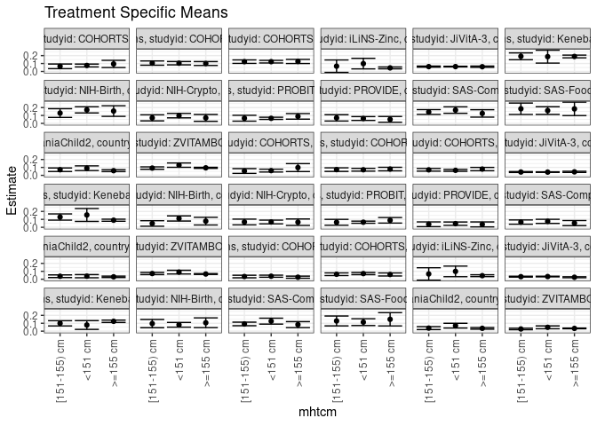

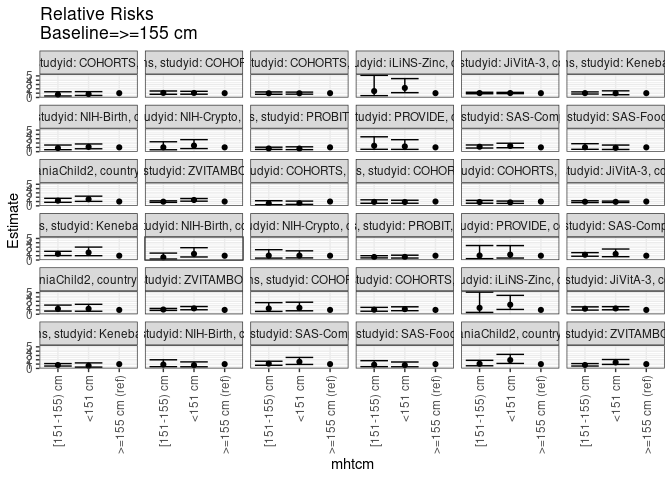

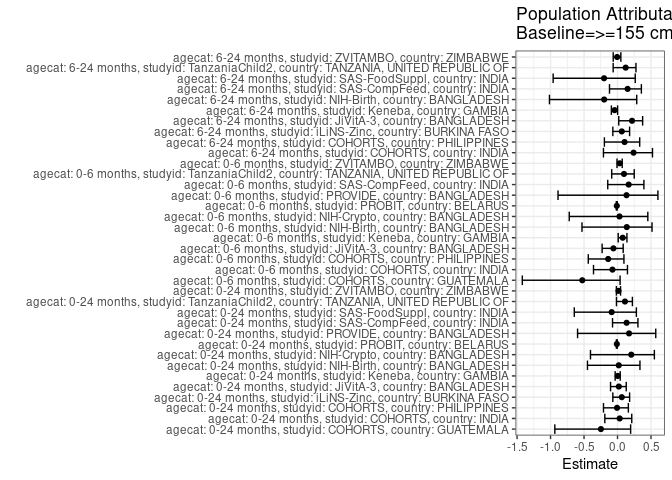

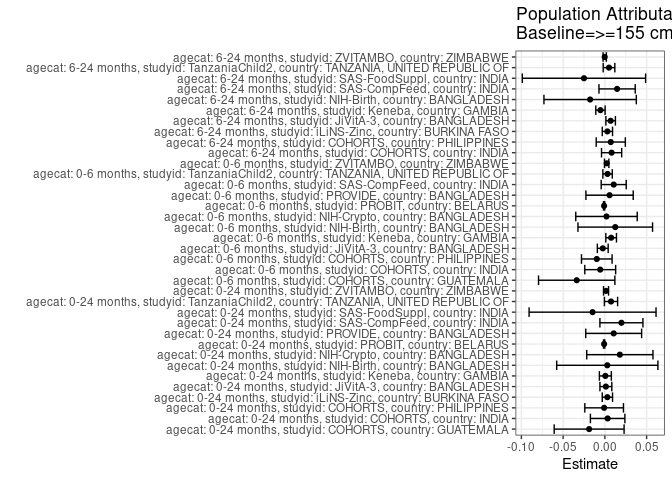

## Results Table

### Parameter: TSM

| agecat | studyid | country | intervention_level | baseline_level | estimate | ci_lower | ci_upper |
| --- | --- | --- | --- | --- | --- | --- | --- |
| 0-24 months | COHORTS | GUATEMALA | >=155 cm | NA | 0.0949285 | 0.0494084 | 0.1404485 |
| 0-24 months | COHORTS | GUATEMALA | <151 cm | NA | 0.0751410 | 0.0572178 | 0.0930642 |
| 0-24 months | COHORTS | GUATEMALA | [151-155) cm | NA | 0.0645860 | 0.0352436 | 0.0939283 |
| 0-24 months | COHORTS | INDIA | >=155 cm | NA | 0.1000882 | 0.0756035 | 0.1245730 |
| 0-24 months | COHORTS | INDIA | <151 cm | NA | 0.1043098 | 0.0834276 | 0.1251919 |
| 0-24 months | COHORTS | INDIA | [151-155) cm | NA | 0.1056226 | 0.0789195 | 0.1323256 |
| 0-24 months | COHORTS | PHILIPPINES | >=155 cm | NA | 0.1263226 | 0.1003493 | 0.1522959 |
| 0-24 months | COHORTS | PHILIPPINES | <151 cm | NA | 0.1235648 | 0.1071502 | 0.1399793 |
| 0-24 months | COHORTS | PHILIPPINES | [151-155) cm | NA | 0.1236048 | 0.1016316 | 0.1455780 |
| 0-24 months | iLiNS-Zinc | BURKINA FASO | >=155 cm | NA | 0.0448276 | 0.0330790 | 0.0565762 |
| 0-24 months | iLiNS-Zinc | BURKINA FASO | <151 cm | NA | 0.0989011 | 0.0320763 | 0.1657259 |
| 0-24 months | iLiNS-Zinc | BURKINA FASO | [151-155) cm | NA | 0.0663717 | -0.0121057 | 0.1448490 |
| 0-24 months | JiVitA-3 | BANGLADESH | >=155 cm | NA | 0.0597840 | 0.0519865 | 0.0675815 |
| 0-24 months | JiVitA-3 | BANGLADESH | <151 cm | NA | 0.0612855 | 0.0569689 | 0.0656021 |
| 0-24 months | JiVitA-3 | BANGLADESH | [151-155) cm | NA | 0.0611017 | 0.0543374 | 0.0678661 |
| 0-24 months | Keneba | GAMBIA | >=155 cm | NA | 0.1892127 | 0.1721113 | 0.2063140 |
| 0-24 months | Keneba | GAMBIA | <151 cm | NA | 0.1871078 | 0.1056445 | 0.2685711 |
| 0-24 months | Keneba | GAMBIA | [151-155) cm | NA | 0.1912604 | 0.1480144 | 0.2345063 |
| 0-24 months | NIH-Birth | BANGLADESH | >=155 cm | NA | 0.1557412 | 0.0888084 | 0.2226740 |
| 0-24 months | NIH-Birth | BANGLADESH | <151 cm | NA | 0.1709917 | 0.1318786 | 0.2101048 |
| 0-24 months | NIH-Birth | BANGLADESH | [151-155) cm | NA | 0.1304998 | 0.0753621 | 0.1856375 |
| 0-24 months | NIH-Crypto | BANGLADESH | >=155 cm | NA | 0.0694651 | 0.0265005 | 0.1124297 |
| 0-24 months | NIH-Crypto | BANGLADESH | <151 cm | NA | 0.0980478 | 0.0699377 | 0.1261579 |
| 0-24 months | NIH-Crypto | BANGLADESH | [151-155) cm | NA | 0.0699478 | 0.0317603 | 0.1081354 |
| 0-24 months | PROBIT | BELARUS | >=155 cm | NA | 0.0886383 | 0.0534346 | 0.1238420 |
| 0-24 months | PROBIT | BELARUS | <151 cm | NA | 0.0640000 | 0.0504110 | 0.0775890 |
| 0-24 months | PROBIT | BELARUS | [151-155) cm | NA | 0.0653266 | 0.0283038 | 0.1023494 |
| 0-24 months | PROVIDE | BANGLADESH | >=155 cm | NA | 0.0507246 | 0.0140860 | 0.0873632 |
| 0-24 months | PROVIDE | BANGLADESH | <151 cm | NA | 0.0616622 | 0.0372331 | 0.0860913 |
| 0-24 months | PROVIDE | BANGLADESH | [151-155) cm | NA | 0.0696203 | 0.0299064 | 0.1093341 |

[output cut: 78 more lines]

### Parameter: E(Y)

| agecat | studyid | country | intervention_level | baseline_level | estimate | ci_lower | ci_upper |
| --- | --- | --- | --- | --- | --- | --- | --- |
| 0-24 months | COHORTS | GUATEMALA | NA | NA | 0.0760784 | 0.0615201 | 0.0906368 |
| 0-24 months | COHORTS | INDIA | NA | NA | 0.1034121 | 0.0897349 | 0.1170893 |
| 0-24 months | COHORTS | PHILIPPINES | NA | NA | 0.1254516 | 0.1136848 | 0.1372183 |
| 0-24 months | iLiNS-Zinc | BURKINA FASO | NA | NA | 0.0478707 | 0.0359037 | 0.0598376 |
| 0-24 months | JiVitA-3 | BANGLADESH | NA | NA | 0.0609979 | 0.0575023 | 0.0644934 |
| 0-24 months | Keneba | GAMBIA | NA | NA | 0.1898110 | 0.1742287 | 0.2053933 |
| 0-24 months | NIH-Birth | BANGLADESH | NA | NA | 0.1586538 | 0.1299648 | 0.1873429 |
| 0-24 months | NIH-Crypto | BANGLADESH | NA | NA | 0.0874172 | 0.0672569 | 0.1075775 |
| 0-24 months | PROBIT | BELARUS | NA | NA | 0.0877385 | 0.0529840 | 0.1224929 |
| 0-24 months | PROVIDE | BANGLADESH | NA | NA | 0.0612855 | 0.0430966 | 0.0794744 |
| 0-24 months | SAS-CompFeed | INDIA | NA | NA | 0.1460432 | 0.1145875 | 0.1774988 |
| 0-24 months | SAS-FoodSuppl | INDIA | NA | NA | 0.1687042 | 0.1323664 | 0.2050420 |
| 0-24 months | TanzaniaChild2 | TANZANIA, UNITED REPUBLIC OF | NA | NA | 0.0661297 | 0.0560993 | 0.0761601 |
| 0-24 months | ZVITAMBO | ZIMBABWE | NA | NA | 0.0962360 | 0.0904057 | 0.1020663 |
| 0-6 months | COHORTS | GUATEMALA | NA | NA | 0.0641148 | 0.0492559 | 0.0789738 |
| 0-6 months | COHORTS | INDIA | NA | NA | 0.0735373 | 0.0616816 | 0.0853930 |
| 0-6 months | COHORTS | PHILIPPINES | NA | NA | 0.0693167 | 0.0602923 | 0.0783411 |
| 0-6 months | JiVitA-3 | BANGLADESH | NA | NA | 0.0413613 | 0.0383739 | 0.0443486 |
| 0-6 months | Keneba | GAMBIA | NA | NA | 0.0968041 | 0.0843285 | 0.1092796 |
| 0-6 months | NIH-Birth | BANGLADESH | NA | NA | 0.0900322 | 0.0675202 | 0.1125442 |
| 0-6 months | NIH-Crypto | BANGLADESH | NA | NA | 0.0662252 | 0.0484753 | 0.0839750 |
| 0-6 months | PROBIT | BELARUS | NA | NA | 0.0870832 | 0.0523350 | 0.1218313 |
| 0-6 months | PROVIDE | BANGLADESH | NA | NA | 0.0418535 | 0.0266676 | 0.0570395 |
| 0-6 months | SAS-CompFeed | INDIA | NA | NA | 0.0636298 | 0.0408673 | 0.0863923 |
| 0-6 months | TanzaniaChild2 | TANZANIA, UNITED REPUBLIC OF | NA | NA | 0.0334888 | 0.0262272 | 0.0407503 |
| 0-6 months | ZVITAMBO | ZIMBABWE | NA | NA | 0.0681168 | 0.0631263 | 0.0731073 |
| 6-24 months | COHORTS | INDIA | NA | NA | 0.0336408 | 0.0254069 | 0.0418747 |
| 6-24 months | COHORTS | PHILIPPINES | NA | NA | 0.0669277 | 0.0576848 | 0.0761707 |
| 6-24 months | iLiNS-Zinc | BURKINA FASO | NA | NA | 0.0478707 | 0.0359037 | 0.0598376 |
| 6-24 months | JiVitA-3 | BANGLADESH | NA | NA | 0.0318896 | 0.0289915 | 0.0347877 |
| 6-24 months | Keneba | GAMBIA | NA | NA | 0.1195185 | 0.1063325 | 0.1327045 |
| 6-24 months | NIH-Birth | BANGLADESH | NA | NA | 0.0885609 | 0.0646203 | 0.1125014 |
| 6-24 months | SAS-CompFeed | INDIA | NA | NA | 0.0971026 | 0.0697212 | 0.1244840 |
| 6-24 months | SAS-FoodSuppl | INDIA | NA | NA | 0.1246883 | 0.0923131 | 0.1570635 |
| 6-24 months | TanzaniaChild2 | TANZANIA, UNITED REPUBLIC OF | NA | NA | 0.0408060 | 0.0321006 | 0.0495115 |
| 6-24 months | ZVITAMBO | ZIMBABWE | NA | NA | 0.0345547 | 0.0306996 | 0.0384098 |

### Parameter: RR

| agecat | studyid | country | intervention_level | baseline_level | estimate | ci_lower | ci_upper |
| --- | --- | --- | --- | --- | --- | --- | --- |
| 0-24 months | COHORTS | GUATEMALA | >=155 cm | >=155 cm | 1.0000000 | 1.0000000 | 1.000000 |
| 0-24 months | COHORTS | GUATEMALA | <151 cm | >=155 cm | 0.7915540 | 0.4633212 | 1.352318 |
| 0-24 months | COHORTS | GUATEMALA | [151-155) cm | >=155 cm | 0.6803648 | 0.3513394 | 1.317519 |
| 0-24 months | COHORTS | INDIA | >=155 cm | >=155 cm | 1.0000000 | 1.0000000 | 1.000000 |
| 0-24 months | COHORTS | INDIA | <151 cm | >=155 cm | 1.0421782 | 0.7596863 | 1.429716 |
| 0-24 months | COHORTS | INDIA | [151-155) cm | >=155 cm | 1.0552946 | 0.7423895 | 1.500084 |
| 0-24 months | COHORTS | PHILIPPINES | >=155 cm | >=155 cm | 1.0000000 | 1.0000000 | 1.000000 |
| 0-24 months | COHORTS | PHILIPPINES | <151 cm | >=155 cm | 0.9781683 | 0.7657111 | 1.249575 |
| 0-24 months | COHORTS | PHILIPPINES | [151-155) cm | >=155 cm | 0.9784849 | 0.7456469 | 1.284029 |
| 0-24 months | iLiNS-Zinc | BURKINA FASO | >=155 cm | >=155 cm | 1.0000000 | 1.0000000 | 1.000000 |
| 0-24 months | iLiNS-Zinc | BURKINA FASO | <151 cm | >=155 cm | 2.2062553 | 1.1131512 | 4.372777 |
| 0-24 months | iLiNS-Zinc | BURKINA FASO | [151-155) cm | >=155 cm | 1.4805990 | 0.4280422 | 5.121396 |
| 0-24 months | JiVitA-3 | BANGLADESH | >=155 cm | >=155 cm | 1.0000000 | 1.0000000 | 1.000000 |
| 0-24 months | JiVitA-3 | BANGLADESH | <151 cm | >=155 cm | 1.0251159 | 0.8903489 | 1.180282 |
| 0-24 months | JiVitA-3 | BANGLADESH | [151-155) cm | >=155 cm | 1.0220416 | 0.8647736 | 1.207911 |
| 0-24 months | Keneba | GAMBIA | >=155 cm | >=155 cm | 1.0000000 | 1.0000000 | 1.000000 |
| 0-24 months | Keneba | GAMBIA | <151 cm | >=155 cm | 0.9888757 | 0.6339022 | 1.542628 |
| 0-24 months | Keneba | GAMBIA | [151-155) cm | >=155 cm | 1.0108223 | 0.7923295 | 1.289567 |
| 0-24 months | NIH-Birth | BANGLADESH | >=155 cm | >=155 cm | 1.0000000 | 1.0000000 | 1.000000 |
| 0-24 months | NIH-Birth | BANGLADESH | <151 cm | >=155 cm | 1.0979221 | 0.6746567 | 1.786735 |
| 0-24 months | NIH-Birth | BANGLADESH | [151-155) cm | >=155 cm | 0.8379273 | 0.4585509 | 1.531176 |
| 0-24 months | NIH-Crypto | BANGLADESH | >=155 cm | >=155 cm | 1.0000000 | 1.0000000 | 1.000000 |
| 0-24 months | NIH-Crypto | BANGLADESH | <151 cm | >=155 cm | 1.4114680 | 0.7138073 | 2.791008 |
| 0-24 months | NIH-Crypto | BANGLADESH | [151-155) cm | >=155 cm | 1.0069491 | 0.4412914 | 2.297680 |
| 0-24 months | PROBIT | BELARUS | >=155 cm | >=155 cm | 1.0000000 | 1.0000000 | 1.000000 |
| 0-24 months | PROBIT | BELARUS | <151 cm | >=155 cm | 0.7220359 | 0.4679692 | 1.114039 |
| 0-24 months | PROBIT | BELARUS | [151-155) cm | >=155 cm | 0.7370027 | 0.5240840 | 1.036423 |
| 0-24 months | PROVIDE | BANGLADESH | >=155 cm | >=155 cm | 1.0000000 | 1.0000000 | 1.000000 |
| 0-24 months | PROVIDE | BANGLADESH | <151 cm | >=155 cm | 1.2156262 | 0.5333591 | 2.770642 |
| 0-24 months | PROVIDE | BANGLADESH | [151-155) cm | >=155 cm | 1.3725136 | 0.5467589 | 3.445383 |

[output cut: 78 more lines]

### Parameter: PAR

| agecat | studyid | country | intervention_level | baseline_level | estimate | ci_lower | ci_upper |
| --- | --- | --- | --- | --- | --- | --- | --- |
| 0-24 months | COHORTS | GUATEMALA | >=155 cm | NA | -0.0188500 | -0.0607127 | 0.0230126 |
| 0-24 months | COHORTS | INDIA | >=155 cm | NA | 0.0033238 | -0.0173183 | 0.0239659 |
| 0-24 months | COHORTS | PHILIPPINES | >=155 cm | NA | -0.0008711 | -0.0240211 | 0.0222789 |
| 0-24 months | iLiNS-Zinc | BURKINA FASO | >=155 cm | NA | 0.0030431 | -0.0031079 | 0.0091941 |
| 0-24 months | JiVitA-3 | BANGLADESH | >=155 cm | NA | 0.0012139 | -0.0059058 | 0.0083336 |
| 0-24 months | Keneba | GAMBIA | >=155 cm | NA | 0.0005984 | -0.0065663 | 0.0077630 |
| 0-24 months | NIH-Birth | BANGLADESH | >=155 cm | NA | 0.0029126 | -0.0577108 | 0.0635360 |
| 0-24 months | NIH-Crypto | BANGLADESH | >=155 cm | NA | 0.0179521 | -0.0217087 | 0.0576130 |
| 0-24 months | PROBIT | BELARUS | >=155 cm | NA | -0.0008998 | -0.0016588 | -0.0001408 |
| 0-24 months | PROVIDE | BANGLADESH | >=155 cm | NA | 0.0105609 | -0.0228968 | 0.0440185 |
| 0-24 months | SAS-CompFeed | INDIA | >=155 cm | NA | 0.0198189 | -0.0059434 | 0.0455813 |
| 0-24 months | SAS-FoodSuppl | INDIA | >=155 cm | NA | -0.0147354 | -0.0907512 | 0.0612803 |
| 0-24 months | TanzaniaChild2 | TANZANIA, UNITED REPUBLIC OF | >=155 cm | NA | 0.0073426 | -0.0005725 | 0.0152578 |
| 0-24 months | ZVITAMBO | ZIMBABWE | >=155 cm | NA | 0.0014001 | -0.0016173 | 0.0044176 |
| 0-6 months | COHORTS | GUATEMALA | >=155 cm | NA | -0.0337276 | -0.0794497 | 0.0119946 |
| 0-6 months | COHORTS | INDIA | >=155 cm | NA | -0.0055692 | -0.0240579 | 0.0129196 |
| 0-6 months | COHORTS | PHILIPPINES | >=155 cm | NA | -0.0096846 | -0.0280132 | 0.0086440 |
| 0-6 months | JiVitA-3 | BANGLADESH | >=155 cm | NA | -0.0025277 | -0.0090145 | 0.0039590 |
| 0-6 months | Keneba | GAMBIA | >=155 cm | NA | 0.0075275 | 0.0011655 | 0.0138896 |
| 0-6 months | NIH-Birth | BANGLADESH | >=155 cm | NA | 0.0124459 | -0.0322217 | 0.0571136 |
| 0-6 months | NIH-Crypto | BANGLADESH | >=155 cm | NA | 0.0019395 | -0.0348689 | 0.0387478 |
| 0-6 months | PROBIT | BELARUS | >=155 cm | NA | -0.0009495 | -0.0016958 | -0.0002033 |
| 0-6 months | PROVIDE | BANGLADESH | >=155 cm | NA | 0.0056216 | -0.0227065 | 0.0339497 |
| 0-6 months | SAS-CompFeed | INDIA | >=155 cm | NA | 0.0105960 | -0.0043934 | 0.0255854 |
| 0-6 months | TanzaniaChild2 | TANZANIA, UNITED REPUBLIC OF | >=155 cm | NA | 0.0032385 | -0.0023957 | 0.0088727 |
| 0-6 months | ZVITAMBO | ZIMBABWE | >=155 cm | NA | 0.0021679 | -0.0004697 | 0.0048054 |
| 6-24 months | COHORTS | INDIA | >=155 cm | NA | 0.0080570 | -0.0040097 | 0.0201237 |
| 6-24 months | COHORTS | PHILIPPINES | >=155 cm | NA | 0.0070618 | -0.0103741 | 0.0244978 |
| 6-24 months | iLiNS-Zinc | BURKINA FASO | >=155 cm | NA | 0.0030431 | -0.0031079 | 0.0091941 |
| 6-24 months | JiVitA-3 | BANGLADESH | >=155 cm | NA | 0.0069125 | 0.0012096 | 0.0126153 |
| 6-24 months | Keneba | GAMBIA | >=155 cm | NA | -0.0052865 | -0.0108741 | 0.0003010 |
| 6-24 months | NIH-Birth | BANGLADESH | >=155 cm | NA | -0.0176489 | -0.0729694 | 0.0376717 |
| 6-24 months | SAS-CompFeed | INDIA | >=155 cm | NA | 0.0146468 | -0.0070739 | 0.0363675 |
| 6-24 months | SAS-FoodSuppl | INDIA | >=155 cm | NA | -0.0250370 | -0.0988793 | 0.0488054 |
| 6-24 months | TanzaniaChild2 | TANZANIA, UNITED REPUBLIC OF | >=155 cm | NA | 0.0049632 | -0.0020083 | 0.0119348 |
| 6-24 months | ZVITAMBO | ZIMBABWE | >=155 cm | NA | -0.0001959 | -0.0021646 | 0.0017727 |

### Parameter: PAF

| agecat | studyid | country | intervention_level | baseline_level | estimate | ci_lower | ci_upper |
| --- | --- | --- | --- | --- | --- | --- | --- |
| 0-24 months | COHORTS | GUATEMALA | >=155 cm | NA | -0.2477710 | -0.9360087 | 0.1958030 |
| 0-24 months | COHORTS | INDIA | >=155 cm | NA | 0.0321417 | -0.1894725 | 0.2124663 |
| 0-24 months | COHORTS | PHILIPPINES | >=155 cm | NA | -0.0069434 | -0.2094688 | 0.1616691 |
| 0-24 months | iLiNS-Zinc | BURKINA FASO | >=155 cm | NA | 0.0635692 | -0.0699048 | 0.1803918 |
| 0-24 months | JiVitA-3 | BANGLADESH | >=155 cm | NA | 0.0199006 | -0.1040058 | 0.1299005 |
| 0-24 months | Keneba | GAMBIA | >=155 cm | NA | 0.0031524 | -0.0353167 | 0.0401920 |
| 0-24 months | NIH-Birth | BANGLADESH | >=155 cm | NA | 0.0183584 | -0.4487850 | 0.3348770 |
| 0-24 months | NIH-Crypto | BANGLADESH | >=155 cm | NA | 0.2053614 | -0.4038413 | 0.5501980 |
| 0-24 months | PROBIT | BELARUS | >=155 cm | NA | -0.0102554 | -0.0173672 | -0.0031934 |
| 0-24 months | PROVIDE | BANGLADESH | >=155 cm | NA | 0.1723224 | -0.5965976 | 0.5709312 |
| 0-24 months | SAS-CompFeed | INDIA | >=155 cm | NA | 0.1357061 | -0.0745365 | 0.3048128 |
| 0-24 months | SAS-FoodSuppl | INDIA | >=155 cm | NA | -0.0873447 | -0.6455813 | 0.2815192 |
| 0-24 months | TanzaniaChild2 | TANZANIA, UNITED REPUBLIC OF | >=155 cm | NA | 0.1110339 | -0.0159658 | 0.2221581 |
| 0-24 months | ZVITAMBO | ZIMBABWE | >=155 cm | NA | 0.0145491 | -0.0172995 | 0.0454007 |
| 0-6 months | COHORTS | GUATEMALA | >=155 cm | NA | -0.5260493 | -1.4216195 | 0.0383186 |
| 0-6 months | COHORTS | INDIA | >=155 cm | NA | -0.0757327 | -0.3586826 | 0.1482920 |
| 0-6 months | COHORTS | PHILIPPINES | >=155 cm | NA | -0.1397155 | -0.4366051 | 0.0958187 |
| 0-6 months | JiVitA-3 | BANGLADESH | >=155 cm | NA | -0.0611135 | -0.2299358 | 0.0845361 |
| 0-6 months | Keneba | GAMBIA | >=155 cm | NA | 0.0777603 | 0.0103269 | 0.1405991 |
| 0-6 months | NIH-Birth | BANGLADESH | >=155 cm | NA | 0.1382389 | -0.5307819 | 0.5148674 |
| 0-6 months | NIH-Crypto | BANGLADESH | >=155 cm | NA | 0.0292857 | -0.7208215 | 0.4524207 |
| 0-6 months | PROBIT | BELARUS | >=155 cm | NA | -0.0109039 | -0.0179334 | -0.0039230 |
| 0-6 months | PROVIDE | BANGLADESH | >=155 cm | NA | 0.1343168 | -0.8884265 | 0.6031577 |
| 0-6 months | SAS-CompFeed | INDIA | >=155 cm | NA | 0.1665252 | -0.1460619 | 0.3938544 |
| 0-6 months | TanzaniaChild2 | TANZANIA, UNITED REPUBLIC OF | >=155 cm | NA | 0.0967038 | -0.0869304 | 0.2493134 |
| 0-6 months | ZVITAMBO | ZIMBABWE | >=155 cm | NA | 0.0318261 | -0.0076201 | 0.0697280 |
| 6-24 months | COHORTS | INDIA | >=155 cm | NA | 0.2395017 | -0.2101042 | 0.5220596 |
| 6-24 months | COHORTS | PHILIPPINES | >=155 cm | NA | 0.1055144 | -0.1961073 | 0.3310763 |
| 6-24 months | iLiNS-Zinc | BURKINA FASO | >=155 cm | NA | 0.0635692 | -0.0699048 | 0.1803918 |
| 6-24 months | JiVitA-3 | BANGLADESH | >=155 cm | NA | 0.2167623 | 0.0186063 | 0.3749080 |
| 6-24 months | Keneba | GAMBIA | >=155 cm | NA | -0.0442317 | -0.0918533 | 0.0013129 |
| 6-24 months | NIH-Birth | BANGLADESH | >=155 cm | NA | -0.1992852 | -1.0162912 | 0.2866681 |
| 6-24 months | SAS-CompFeed | INDIA | >=155 cm | NA | 0.1508386 | -0.1198073 | 0.3560721 |
| 6-24 months | SAS-FoodSuppl | INDIA | >=155 cm | NA | -0.2007964 | -0.9611224 | 0.2647517 |
| 6-24 months | TanzaniaChild2 | TANZANIA, UNITED REPUBLIC OF | >=155 cm | NA | 0.1216302 | -0.0649521 | 0.2755228 |
| 6-24 months | ZVITAMBO | ZIMBABWE | >=155 cm | NA | -0.0056696 | -0.0642833 | 0.0497160 |